# ST563 project_NT

This project focuses on machine learning to build growth prediction models for clipping yield prediction in golf courses to optimize N applications. I have used historical clipping data obtained from previous field studies to build a yield prediction model. The reponse variable is clipping yield (clipping (g/m2/day)). The features that will be included in the model are given below in the table. My plan is to build several models in search of a simple and accurate model.

## Variable Used in Model

| Variable | Variable Name |
| --- | --- |
| Clipping Yield | Clipping (g/m²/day) |
| Height of cut | HOC |
| Accumulative days turf grows | Days grow |
| Biweekly N rate | N rate (kg/ha/2wks) |
| Plant growth regulator rate | TE (g/ha/GDD) |
| Three-day average soil moisture | Soil moist |
| Weekly walking traffic | Traffic (min/week/plot) |
| Accumulative GDD at PGR application | Cumulative GDD @ PGR application date |
| Daily NDRE | NDRE |
| Maximum air temp (day 0 to 6) | 1st to 7th Maximum Air Temperature (°C) |
| Average air temp (day 0 to 6) | 1st to 7th Average Air Temperature (°C) |
| Minimum air temp (day 0 to 6) | 1st to 7th Minimum Air Temperature (°C) |
| Maximum relative humidity (day 0 to 6) | 1st to 7th Maximum Relative Humidity (%) |
| Average relative humidity (day 0 to 6) | 1st to 7th Average Relative Humidity (%) |
| Minimum relative humidity (day 0 to 6) | 1st to 7th Minimum Relative Humidity (%) |
| Accumulative precipitation (day 0 to 6) | 1st to 7th Total Precipitation (mm) |
| Maximum soil temp (day 0 to 6) | 1st to 7th Maximum Soil Temperature (°C) |
| Average soil temp (day 0 to 6) | 1st to 7th Average Soil Temperature (°C) |
| Minimum soil temp (day 0 to 6) | 1st to 7th Minimum Soil Temperature (°C) |
| Maximum soil moisture (day 0 to 6) | 1st to 7th Maximum Soil Moisture (m³/m³) |
| Average soil moisture (day 0 to 6) | 1st to 7th Average Soil Moisture (m³/m³) |
| Minimum soil moisture (day 0 to 6) | 1st to 7th Minimum Soil Moisture (m³/m³) |

```python
import pandas as pd
import numpy as np
import matplotlib.pyplot as plt

from sklearn.impute import SimpleImputer
from sklearn.preprocessing import StandardScaler, MinMaxScaler
from sklearn.model_selection import train_test_split, GridSearchCV, KFold
from sklearn.feature_selection import SelectKBest, f_regression
from sklearn.neighbors import KNeighborsRegressor
from sklearn.linear_model import Lasso, LinearRegression
from sklearn.tree import DecisionTreeRegressor
from sklearn.ensemble import RandomForestRegressor
from sklearn.svm import SVR
from sklearn.metrics import mean_squared_error, mean_absolute_error, r2_score
from sklearn.inspection import PartialDependenceDisplay

from pygam import LinearGAM, s
from xgboost import XGBRegressor
from joblib import dump
```

Step 1: Import data

```python
# Load your original data from an Excel file
data = pd.read_excel(r'G:\My Drive\Project\NRCC 2023 data.xlsx')
print(data.head(10))
```

```
     trt location    HOC  plot       date  clipping mass (g/10.94 ft2)  \
0  N*PGR     NRCC  0.085     1 2023-06-08                        0.568
1  N*PGR     NRCC  0.085     2 2023-06-08                        0.984
2  N*PGR     NRCC  0.085     3 2023-06-08                        1.269
3  N*PGR     NRCC  0.085     4 2023-06-08                        1.077
4  N*PGR     NRCC  0.085     5 2023-06-08                        1.533
5  N*PGR     NRCC  0.085     6 2023-06-08                        0.914
6  N*PGR     NRCC  0.085     7 2023-06-08                        1.640
7  N*PGR     NRCC  0.085     8 2023-06-08                        2.065
8  N*PGR     NRCC  0.085     9 2023-06-08                        4.816
9  N*PGR     NRCC  0.085    10 2023-06-08                        2.043

   clipping (g/m2/day)  Days grow  trt #  N rate (lbs/1000ft2/2wks)  ...  \
0             0.558275          1      3                        0.2  ...
1             0.967152          1      6                        0.1  ...
```

[output cut: 70 more lines]

Step 2: Data Preprocessing: Iputation and Normalization

```python
print(data.dtypes)  # Verify all are numeric
```

```
trt                                          object
location                                     object
HOC                                         float64
plot                                          int64
date                                 datetime64[ns]
                                          ...
3rd Minimum Soil Moisture (m3/m3)           float64
4th Minimum Soil Moisture (m3/m3)           float64
5th Minimum Soil Moisture (m3/m3)           float64
6th Minimum Soil Moisture (m3/m3)           float64
7th Minimum Soil Moisture (m3/m3)           float64
Length: 128, dtype: object
```

```python
# Check data types and summary statistics
print("Data Info:")
data.info()  # Check for correct data types
print("\nSummary Statistics:")
print(data.describe())  # Summary statistics for numerical variables
```

```
Data Info:
<class 'pandas.core.frame.DataFrame'>
RangeIndex: 1440 entries, 0 to 1439
Columns: 128 entries, trt to 7th Minimum Soil Moisture (m3/m3)
dtypes: datetime64[ns](3), float64(118), int64(5), object(2)
memory usage: 1.4+ MB

Summary Statistics:
               HOC         plot                 date  \
count  1440.000000  1440.000000                 1440
mean      0.134333    12.500000  2023-08-21 12:00:00
min       0.085000     1.000000  2023-06-08 00:00:00
25%       0.125000     6.750000  2023-07-20 00:00:00
50%       0.125000    12.500000  2023-08-30 00:00:00
75%       0.165000    18.250000  2023-09-19 00:00:00
max       0.165000    24.000000  2023-10-05 00:00:00
std       0.026709     6.924591                  NaN

       clipping mass (g/10.94 ft2)  clipping (g/m2/day)    Days grow  \
count                  1392.000000          1395.000000  1440.000000
mean                      0.754572             0.523189     2.100000
min                       0.000000             0.000000     1.000000
25%                       0.078000             0.037988     1.000000
50%                       0.243000             0.117945     2.000000
75%                       0.880000             0.435415     3.000000
max                       8.932000             5.818639     5.000000
std                       1.178547             0.921673     1.248098

             trt #  N rate (lbs/1000ft2/2wks)  TE (g/ha/GDD)  \
count  1440.000000                1440.000000    1440.000000
mean      4.500000                   0.175000      17.000000
min       1.000000                   0.000000       0.000000
25%       2.750000                   0.075000       0.000000
50%       4.500000                   0.150000      17.000000
75%       6.250000                   0.250000      34.000000
max       8.000000                   0.400000      34.000000
std       2.292084                   0.147953      17.005906

       N rate (kg/ha/2wks)  ...  6th Average Soil Moisture (m3/m3)  \
count          1440.000000  ...                        1440.000000
```

[output cut: 135 more lines]

```
75%                             0.340000                           0.340000
max                             0.390000                           0.380000
std                             0.061629                           0.061046

       7th Minimum Soil Moisture (m3/m3)
count                        1440.000000
mean                            0.276333
min                             0.200000
25%                             0.220000
50%                             0.260000
75%                             0.350000
max                             0.370000
std                             0.061854

[8 rows x 126 columns]
```

```python
print(data.describe())  # Check ranges for validity
```

```
               HOC         plot                 date  \
count  1440.000000  1440.000000                 1440
mean      0.134333    12.500000  2023-08-21 12:00:00
min       0.085000     1.000000  2023-06-08 00:00:00
25%       0.125000     6.750000  2023-07-20 00:00:00
50%       0.125000    12.500000  2023-08-30 00:00:00
75%       0.165000    18.250000  2023-09-19 00:00:00
max       0.165000    24.000000  2023-10-05 00:00:00
std       0.026709     6.924591                  NaN

       clipping mass (g/10.94 ft2)  clipping (g/m2/day)    Days grow  \
count                  1392.000000          1395.000000  1440.000000
mean                      0.754572             0.523189     2.100000
min                       0.000000             0.000000     1.000000
25%                       0.078000             0.037988     1.000000
50%                       0.243000             0.117945     2.000000
75%                       0.880000             0.435415     3.000000
max                       8.932000             5.818639     5.000000
std                       1.178547             0.921673     1.248098

             trt #  N rate (lbs/1000ft2/2wks)  TE (g/ha/GDD)  \
count  1440.000000                1440.000000    1440.000000
mean      4.500000                   0.175000      17.000000
min       1.000000                   0.000000       0.000000
25%       2.750000                   0.075000       0.000000
50%       4.500000                   0.150000      17.000000
75%       6.250000                   0.250000      34.000000
max       8.000000                   0.400000      34.000000
std       2.292084                   0.147953      17.005906

       N rate (kg/ha/2wks)  ...  6th Average Soil Moisture (m3/m3)  \
count          1440.000000  ...                        1440.000000
mean              8.523450  ...                           0.280667
min               0.000000  ...                           0.200000
25%               3.652907  ...                           0.220000
50%               7.305814  ...                           0.270000
75%              12.176357  ...                           0.350000
max              19.482172  ...                           0.400000
std               7.206133  ...                           0.062628

```

[output cut: 36 more lines]

```
75%                             0.340000                           0.340000
max                             0.390000                           0.380000
std                             0.061629                           0.061046

       7th Minimum Soil Moisture (m3/m3)
count                        1440.000000
mean                            0.276333
min                             0.200000
25%                             0.220000
50%                             0.260000
75%                             0.350000
max                             0.370000
std                             0.061854

[8 rows x 126 columns]
```

Summary show height of cut (HOC) ranges from 0.085 to 0.165, which is expected. clipping (g/m2/day) ranges from 0 to 5.82, consistent with expected yields. No extreme outliers were detected.

```python
# Separate features and target variable

X = data[[ 'HOC', 'Days grow', 'N rate (kg/ha/2wks)', 'TE (g/ha/GDD)','soil moist', 'traffic (min/week/plot)', 'Cumulative GDD @ PGR application date','NDRE' , '1st Maximum Air Temperature (C)', '2nd Maximum Air Temperature (C)', '3rd Maximum Air Temperature (C)', '4th Maximum Air Temperature (C)', '5th Maximum Air Temperature (C)', '6th Maximum Air Temperature (C)', '7th Maximum Air Temperature (C)',  '1st Average Air Temperature (C)', '2nd Average Air Temperature (C)', '3rd Average Air Temperature (C)', '4th Average Air Temperature (C)', '5th Average Air Temperature (C)', '6th Average Air Temperature (C)', '7th Average Air Temperature (C)',  '1st Minimum Air Temperature (C)', '2nd Minimum Air Temperature (C)', '3rd Minimum Air Temperature (C)', '4th Minimum Air Temperature (C)', '5th Minimum Air Temperature (C)', '6th Minimum Air Temperature (C)', '7th Minimum Air Temperature (C)', '1st Maximum Relative Humidity (%)', '2nd Maximum Relative Humidity (%)', '3rd Maximum Relative Humidity (%)', '4th Maximum Relative Humidity (%)', '5th Maximum Relative Humidity (%)', '6th Maximum Relative Humidity (%)', '7th Maximum Relative Humidity (%)',  '1st Average Relative Humidity (%)', '2nd Average Relative Humidity (%)', '3rd Average Relative Humidity (%)', '4th Average Relative Humidity (%)', '5th Average Relative Humidity (%)', '6th Average Relative Humidity (%)', '7th Average Relative Humidity (%)',  '1st Minimum Relative Humidity (%)', '2nd Minimum Relative Humidity (%)', '3rd Minimum Relative Humidity (%)', '4th Minimum Relative Humidity (%)', '5th Minimum Relative Humidity (%)', '6th Minimum Relative Humidity (%)', '7th Minimum Relative Humidity (%)',  '1st Total Precipitation (mm)', '2nd Total Precipitation (mm)', '3rd Total Precipitation (mm)', '4th Total Precipitation (mm)', '5th Total Precipitation (mm)', '6th Total Precipitation (mm)', '7th Total Precipitation (mm)', '1st Maximum Soil Temperature (C)', '2nd Maximum Soil Temperature (C)', '3rd Maximum Soil Temperature (C)', '4th Maximum Soil Temperature (C)', '5th Maximum Soil Temperature (C)', '6th Maximum Soil Temperature (C)', '7th Maximum Soil Temperature (C)',  '1st Average Soil Temperature (C)', '2nd Average Soil Temperature (C)', '3rd Average Soil Temperature (C)', '4th Average Soil Temperature (C)', '5th Average Soil Temperature (C)', '6th Average Soil Temperature (C)', '7th Average Soil Temperature (C)',  '1st Minimum Soil Temperature (C)', '2nd Minimum Soil Temperature (C)', '3rd Minimum Soil Temperature (C)', '4th Minimum Soil Temperature (C)', '5th Minimum Soil Temperature (C)', '6th Minimum Soil Temperature (C)', '7th Minimum Soil Temperature (C)',  '1st Maximum Soil Moisture (m3/m3)', '2nd Maximum Soil Moisture (m3/m3)', '3rd Maximum Soil Moisture (m3/m3)', '4th Maximum Soil Moisture (m3/m3)', '5th Maximum Soil Moisture (m3/m3)', '6th Maximum Soil Moisture (m3/m3)', '7th Maximum Soil Moisture (m3/m3)', '1st Average Soil Moisture (m3/m3)', '2nd Average Soil Moisture (m3/m3)', '3rd Average Soil Moisture (m3/m3)', '4th Average Soil Moisture (m3/m3)', '5th Average Soil Moisture (m3/m3)', '6th Average Soil Moisture (m3/m3)', '7th Average Soil Moisture (m3/m3)',  '1st Minimum Soil Moisture (m3/m3)', '2nd Minimum Soil Moisture (m3/m3)', '3rd Minimum Soil Moisture (m3/m3)', '4th Minimum Soil Moisture (m3/m3)', '5th Minimum Soil Moisture (m3/m3)', '6th Minimum Soil Moisture (m3/m3)', '7th Minimum Soil Moisture (m3/m3)']]
y = data ['clipping (g/m2/day)']  # Target variable
```

2.1. Imputation (Handle Missing Values)

I will impute the missing values to preserve sample size instead of removing the data

```python
# Check for NaN values immediately after loading
print("NaN values after loading:", data.isna().sum().sum())
```

```
NaN values after loading: 24805
```

```python
# Impute missing values
imputer = SimpleImputer(strategy='mean')
X_imputed = pd.DataFrame(imputer.fit_transform(X), columns=X.columns)
y_imputed = pd.Series(imputer.fit_transform(y.values.reshape(-1, 1)).flatten(), name='clipping (g/m2/day)')
```

2.2 Normalization

Feature Scaling: Normalize or standardize features if necessary.

Some models require scaling, such as kNN or regularized regression models.

For models like Random Forest, Decision Trees, and Gradient Boosting, scaling generally has little to no impact on performance. This is because these models are non-parametric and are based on decision trees, which do not rely on the magnitude of feature values to make splits.

However, for models like Support Vector Machines (SVM), Linear Regression, or Neural Networks, scaling can make a big difference because these models are sensitive to the scale of the input features.

```python
#Scaling only the features NOT target. (e.g., certain models like SVR may benefit from scaling the target as well, but RandomForest typically does not require target scaling)
# Normalize features
from sklearn.preprocessing import StandardScaler

scaler = StandardScaler()
X_normalized = pd.DataFrame(scaler.fit_transform(X_imputed), columns=X_imputed.columns)
```

Step 3. Data Partitioning: Training and Testing

Split Data into Train and Test Sets: Split your data into training and testing sets to evaluate your model's performance later on the unseen data. Cross-validation (e.g., K-fold cross-validation) ensure that the evaluation is more robust and not dependent on how the data is split.

I split the data into: df_train and df test. df_test was set aside for the final evaluation of the model, providing a benchmark of its performance on unseen data that did not participate in training.

```python
# Split the data into training (80%) and testing (20%) sets
X_train, X_test, y_train, y_test = train_test_split(X_normalized, y_imputed, test_size=0.2, random_state=42)

# If you want to save the splits
train_data = pd.concat([X_train, y_train], axis=1)
test_data = pd.concat([X_test, y_test], axis=1)

# Save the training and testing sets into two separate CSV files; saving the processed data in a format that better preserves data types, like .csv or .parquet
train_data.to_csv('NRCC 2023 train_data.csv', index=False)
test_data.to_csv('NRCC 2023 test_data.csv', index=False)
```

```python
# after training a model, to visualize the feature importances
feature_names_model = [ 'HOC', 'Days grow', 'N rate (kg/ha/2wks)', 'TE (g/ha/GDD)','soil moist', 'traffic (min/week/plot)', 'Cumulative GDD @ PGR application date','NDRE' , '1st Maximum Air Temperature (C)', '2nd Maximum Air Temperature (C)', '3rd Maximum Air Temperature (C)', '4th Maximum Air Temperature (C)', '5th Maximum Air Temperature (C)', '6th Maximum Air Temperature (C)', '7th Maximum Air Temperature (C)',  '1st Average Air Temperature (C)', '2nd Average Air Temperature (C)', '3rd Average Air Temperature (C)', '4th Average Air Temperature (C)', '5th Average Air Temperature (C)', '6th Average Air Temperature (C)', '7th Average Air Temperature (C)',  '1st Minimum Air Temperature (C)', '2nd Minimum Air Temperature (C)', '3rd Minimum Air Temperature (C)', '4th Minimum Air Temperature (C)', '5th Minimum Air Temperature (C)', '6th Minimum Air Temperature (C)', '7th Minimum Air Temperature (C)', '1st Maximum Relative Humidity (%)', '2nd Maximum Relative Humidity (%)', '3rd Maximum Relative Humidity (%)', '4th Maximum Relative Humidity (%)', '5th Maximum Relative Humidity (%)', '6th Maximum Relative Humidity (%)', '7th Maximum Relative Humidity (%)',  '1st Average Relative Humidity (%)', '2nd Average Relative Humidity (%)', '3rd Average Relative Humidity (%)', '4th Average Relative Humidity (%)', '5th Average Relative Humidity (%)', '6th Average Relative Humidity (%)', '7th Average Relative Humidity (%)',  '1st Minimum Relative Humidity (%)', '2nd Minimum Relative Humidity (%)', '3rd Minimum Relative Humidity (%)', '4th Minimum Relative Humidity (%)', '5th Minimum Relative Humidity (%)', '6th Minimum Relative Humidity (%)', '7th Minimum Relative Humidity (%)',  '1st Total Precipitation (mm)', '2nd Total Precipitation (mm)', '3rd Total Precipitation (mm)', '4th Total Precipitation (mm)', '5th Total Precipitation (mm)', '6th Total Precipitation (mm)', '7th Total Precipitation (mm)', '1st Maximum Soil Temperature (C)', '2nd Maximum Soil Temperature (C)', '3rd Maximum Soil Temperature (C)', '4th Maximum Soil Temperature (C)', '5th Maximum Soil Temperature (C)', '6th Maximum Soil Temperature (C)', '7th Maximum Soil Temperature (C)',  '1st Average Soil Temperature (C)', '2nd Average Soil Temperature (C)', '3rd Average Soil Temperature (C)', '4th Average Soil Temperature (C)', '5th Average Soil Temperature (C)', '6th Average Soil Temperature (C)', '7th Average Soil Temperature (C)',  '1st Minimum Soil Temperature (C)', '2nd Minimum Soil Temperature (C)', '3rd Minimum Soil Temperature (C)', '4th Minimum Soil Temperature (C)', '5th Minimum Soil Temperature (C)', '6th Minimum Soil Temperature (C)', '7th Minimum Soil Temperature (C)',  '1st Maximum Soil Moisture (m3/m3)', '2nd Maximum Soil Moisture (m3/m3)', '3rd Maximum Soil Moisture (m3/m3)', '4th Maximum Soil Moisture (m3/m3)', '5th Maximum Soil Moisture (m3/m3)', '6th Maximum Soil Moisture (m3/m3)', '7th Maximum Soil Moisture (m3/m3)', '1st Average Soil Moisture (m3/m3)', '2nd Average Soil Moisture (m3/m3)', '3rd Average Soil Moisture (m3/m3)', '4th Average Soil Moisture (m3/m3)', '5th Average Soil Moisture (m3/m3)', '6th Average Soil Moisture (m3/m3)', '7th Average Soil Moisture (m3/m3)',  '1st Minimum Soil Moisture (m3/m3)', '2nd Minimum Soil Moisture (m3/m3)', '3rd Minimum Soil Moisture (m3/m3)', '4th Minimum Soil Moisture (m3/m3)', '5th Minimum Soil Moisture (m3/m3)', '6th Minimum Soil Moisture (m3/m3)', '7th Minimum Soil Moisture (m3/m3)']
```

Step 4 Initialize and fit the model (training models)

4.1 k-Nearest Neighbors (kNN)

Type: Non-parametric model.

Tuning Parameters: k (number of neighbors), metric (distance metric).

Inference: Does not perform inference.

Variable Selection: No automatic variable selection

Standardization of predictors: Yes, it requires feature scaling.

```python
# 1. k-Nearest Neighbors (kNN)

# 1. Define k range
knn_param_grid = {'n_neighbors': range(1, 21)}

# 2. Set up GridSearchCV
knn = GridSearchCV(KNeighborsRegressor(), knn_param_grid, cv=5, scoring='neg_mean_squared_error')

# 3. Fit on standardized training data
knn.fit(X_train, y_train)

# 4. Store best model
models = {}
models['kNN'] = knn.best_estimator_
```

```python
# 5. Predict on test set
y_pred_knn = models['kNN'].predict(X_test)

# 6. Evaluate model
mae_knn = mean_absolute_error(y_test, y_pred_knn)
mse_knn = mean_squared_error(y_test, y_pred_knn)
rmse_knn = np.sqrt(mse_knn)
r2_knn = r2_score(y_test, y_pred_knn)

# 7. Compute CV RMSE
cv_mse_knn = -knn.cv_results_['mean_test_score'][knn.best_index_]
cv_rmse_knn = np.sqrt(cv_mse_knn)

# 8. Print results
print("kNN Results:")
print(f"Best k: {knn.best_params_['n_neighbors']}")
print(f"CV RMSE: {cv_rmse_knn:.2f}")
print(f"Test MAE: {mae_knn:.2f}, RMSE: {rmse_knn:.2f}, R²: {r2_knn:.2f}")
```

```
kNN Results:
Best k: 10
CV RMSE: 0.61
Test MAE: 0.29, RMSE: 0.58, R²: 0.62
```

4.2 Linear regression

Type: Parametric model.

Tuning Parameters: None (No regularization parameter).

Inference: Yes, you can perform inference and interpret coefficients.

Variable Selection: Linear regression does not perform explicit variable selection.

Standardization: Standardization is not strictly necessary but often recommended if features have different scales.

```python
#2 Linear regression

# 1. Define model (no parameters to tune)
lr = LinearRegression()
# 2. Set up custom KFold and GridSearchCV
kf = KFold(n_splits=4, shuffle=True, random_state=42)  # Custom CV with 4 folds
lr_grid = GridSearchCV(lr, param_grid={}, cv=kf, scoring='neg_mean_squared_error')  # Empty param_grid since no tuning

# 3. Fit model
lr_grid.fit(X_train, y_train)

# 4. Store best model
models = {}
models['Linear Regression'] = lr_grid.best_estimator_
```

```python
# 5. Predict on test set
y_pred_lr = models['Linear Regression'].predict(X_test)

# 6. Evaluate model
mae_lr = mean_absolute_error(y_test, y_pred_lr)
mse_lr = mean_squared_error(y_test, y_pred_lr)
rmse_lr = np.sqrt(mse_lr)
r2_lr = r2_score(y_test, y_pred_lr)

# 7. Compute CV RMSE
cv_mse_lr = -lr_grid.cv_results_['mean_test_score'][0]  # Only one "param" set, so index 0
cv_rmse_lr = np.sqrt(cv_mse_lr)

# 8. Print results
print("Linear Regression Results:")
print(f"CV RMSE: {cv_rmse_lr:.2f}")
print(f"Test MAE: {mae_lr:.2f}, RMSE: {rmse_lr:.2f}, R²: {r2_lr:.2f}")
```

```
Linear Regression Results:
CV RMSE: 0.65
Test MAE: 0.40, RMSE: 0.67, R²: 0.50
```

Regularized Linear Regression (Lasso)

Description: Parametric model. Tuning parameter: alpha (L1 penalty strength). Allows inference (coefficients interpretable). Performs variable selection (shrinks some coefficients to 0). Standardization recommended.

```python
# 2. Regularized Linear Regression (Lasso)

# 1. Define alpha range
lasso_param_grid = {'alpha': [0.001, 0.01, 0.1, 1, 10,100]}

# 2. Set up custom KFold and GridSearchCV
kf = KFold(n_splits=4, shuffle=True, random_state=42)  # Custom CV with 4 folds
lasso = GridSearchCV(Lasso(max_iter=10000, tol=1e-3), lasso_param_grid, cv=kf, scoring='neg_mean_squared_error')

# 3. Fit model
lasso.fit(X_train, y_train)

# 4. Store best model
models = {}
models['Lasso'] = lasso.best_estimator_
```

```python
# 5. Predict on test set
y_pred_lasso = models['Lasso'].predict(X_test)

# 6. Evaluate model
mae_lasso = mean_absolute_error(y_test, y_pred_lasso)
mse_lasso = mean_squared_error(y_test, y_pred_lasso)
rmse_lasso = np.sqrt(mse_lasso)
r2_lasso = r2_score(y_test, y_pred_lasso)

# 7. Compute CV RMSE
cv_mse_lasso = -lasso.cv_results_['mean_test_score'][lasso.best_index_]
cv_rmse_lasso = np.sqrt(cv_mse_lasso)

# 8. Print results
print("Lasso Results:")
print(f"Best alpha: {lasso.best_params_['alpha']}")
print(f"CV RMSE: {cv_rmse_lasso:.2f}")
print(f"Test MAE: {mae_lasso:.2f}, RMSE: {rmse_lasso:.2f}, R²: {r2_lasso:.2f}")
```

```
Lasso Results:
Best alpha: 0.001
CV RMSE: 0.65
Test MAE: 0.40, RMSE: 0.67, R²: 0.50
```

4.3 Generalized Additive Model (GAM) Description:

Type: Non-parametric model.

Tuning Parameters: spline basis (Number of knots).

Inference: Yes (visualize smooth terms).

Variable Selection: No inherent variable selection but allows spline fitting.

Standardization: Not required.

```python
# 1. Pre-select the top k features (e.g., 10) using SelectKBest
k = 15  # Number of features to select
selector = SelectKBest(score_func=f_regression, k=k)
X_train_selected = selector.fit_transform(X_train, y_train)
X_test_selected = selector.transform(X_test)  # Apply the same selection to test data

# Get the number of selected features (should match k)
n_selected_features = X_train_selected.shape[1]

# 2. Define model using spline terms for all selected features
spline_terms = [s(i) for i in range(n_selected_features)]

# Combine spline terms using addition (no sum() needed)
if len(spline_terms) > 1:
    gam = LinearGAM(spline_terms[0] + sum(spline_terms[1:], spline_terms[0]))
else:
    gam = LinearGAM(spline_terms[0])  # Handle case with only 1 feature

# 3. Fit model (no GridSearchCV due to simplicity)
gam.fit(X_train_selected, y_train)

# 4. Store model
models['GAM'] = gam
```

```python
#15 selected features

# Get the indices of the selected features
selected_indices = selector.get_support(indices=True)

# Since X_train is a pandas DataFrame, get the 10 selected feature names
selected_features = X_train.columns[selected_indices].tolist()
print("Top 10 selected features:")
for feature in selected_features:
    print(feature)
```

```
Top 10 selected features:
HOC
Days grow
soil moist
Cumulative GDD @ PGR application date
NDRE
2nd Average Air Temperature (C)
3rd Average Air Temperature (C)
1st Maximum Relative Humidity (%)
2nd Maximum Relative Humidity (%)
1st Average Relative Humidity (%)
2nd Average Relative Humidity (%)
3rd Average Relative Humidity (%)
2nd Minimum Relative Humidity (%)
6th Total Precipitation (mm)
7th Total Precipitation (mm)
```

```python
# Predict on the test set
y_pred = models['GAM'].predict(X_test_selected)

# Model evaluation
# Calculate evaluation metrics
mae = mean_absolute_error(y_test, y_pred)
mse = mean_squared_error(y_test, y_pred)
r2 = r2_score(y_test, y_pred)
rmse = np.sqrt(mse)

# Print the evaluation metrics
print(f"MAE: {mae:.2f}, MSE: {mse:.2f}, RMSE: {rmse:.2f}, R²: {r2:.2f}")
print(f"Using {k} out of {X_train.shape[1]} total features")
```

```
MAE: 0.37, MSE: 0.48, RMSE: 0.70, R²: 0.45
Using 15 out of 99 total features
```

```python
# 1. Pre-select the top k features
k = 15  # Number of features to select
selector = SelectKBest(score_func=f_regression, k=k)
X_train_selected = selector.fit_transform(X_train, y_train)
X_test_selected = selector.transform(X_test)

# Get the number of selected features
n_selected_features = X_train_selected.shape[1]

# 2. Define spline terms for all selected features and combine with +
spline_terms = sum([s(i) for i in range(n_selected_features)], s(0))  # Start with s(0) and add others

# 3. Set up custom KFold and manual CV for tuning 'lam'
kf = KFold(n_splits=4, shuffle=True, random_state=42)
lam_values = [0.1, 1, 10, 100]  # Regularization parameter values
cv_rmse_scores = []

for lam in lam_values:
    gam = LinearGAM(spline_terms, lam=lam)
    fold_rmse = []
    for train_idx, val_idx in kf.split(X_train_selected):
        X_tr, X_val = X_train_selected[train_idx], X_train_selected[val_idx]
        y_tr, y_val = y_train.iloc[train_idx], y_train.iloc[val_idx]  # Use .iloc for positional indexing
        gam.fit(X_tr, y_tr)
        y_pred_val = gam.predict(X_val)
        mse = mean_squared_error(y_val, y_pred_val)
        fold_rmse.append(np.sqrt(mse))
    cv_rmse_scores.append(np.mean(fold_rmse))

# 4. Select best lam and fit final model
best_lam_idx = np.argmin(cv_rmse_scores)
best_lam = lam_values[best_lam_idx]
gam = LinearGAM(spline_terms, lam=best_lam)
gam.fit(X_train_selected, y_train)

# 5. Store best model
models = {}
models['GAM'] = gam

# 6. Predict on test set
y_pred_gam = models['GAM'].predict(X_test_selected)

# 7. Evaluate model
mae_gam = mean_absolute_error(y_test, y_pred_gam)
mse_gam = mean_squared_error(y_test, y_pred_gam)
rmse_gam = np.sqrt(mse_gam)
r2_gam = r2_score(y_test, y_pred_gam)

# 8. CV RMSE from best lam
cv_rmse_gam = cv_rmse_scores[best_lam_idx]

# 9. Print results
print("GAM Results:")
print(f"Best lam: {best_lam}")
print(f"CV RMSE: {cv_rmse_gam:.2f}")
print(f"Test MAE: {mae_gam:.2f}, RMSE: {rmse_gam:.2f}, R²: {r2_gam:.2f}")
print(f"Using {k} out of {X_train.shape[1]} total features")
```

```
GAM Results:
Best lam: 100
CV RMSE: 0.65
Test MAE: 0.37, RMSE: 0.69, R²: 0.46
Using 15 out of 99 total features
```

4.4 Decision Tree Description:

Type: Non-parametric model.

Tuning Parameters: max_depth, min_samples_split, etc.

Inference: limited inference (Can provide variable importance).

Variable Selection: Yes, through tree structure.

Standardization: Not required.

```python
#4 Decision tree

# 1. Define depth range
dt_param_grid = {'max_depth': range(3, 11)}

# 2. Set up custom KFold and GridSearchCV
kf = KFold(n_splits=4, shuffle=True, random_state=42)  # Custom CV with 4 folds
dt = GridSearchCV(DecisionTreeRegressor(random_state=42), dt_param_grid, cv=kf, scoring='neg_mean_squared_error')

# 3. Fit model
dt.fit(X_train, y_train)

# 4. Store best model
models = {}
models['Decision Tree'] = dt.best_estimator_
```

```python
# 5. Predict on test set
y_pred_dt = models['Decision Tree'].predict(X_test)

# 6. Evaluate model
mae_dt = mean_absolute_error(y_test, y_pred_dt)
mse_dt = mean_squared_error(y_test, y_pred_dt)
rmse_dt = np.sqrt(mse_dt)
r2_dt = r2_score(y_test, y_pred_dt)

# 7. Compute CV RMSE
cv_mse_dt = -dt.cv_results_['mean_test_score'][dt.best_index_]
cv_rmse_dt = np.sqrt(cv_mse_dt)

# 8. Print results
print("Decision Tree Results:")
print(f"Best max_depth: {dt.best_params_['max_depth']}")
print(f"CV RMSE: {cv_rmse_dt:.2f}")
print(f"Test MAE: {mae_dt:.2f}, RMSE: {rmse_dt:.2f}, R²: {r2_dt:.2f}")
```

```
Decision Tree Results:
Best max_depth: 3
CV RMSE: 0.71
Test MAE: 0.41, RMSE: 0.73, R²: 0.41
```

5.5 Random Forest (Ensemble) Description:

Type: Non-parametric method.

Tuning Parameters: n_estimators, max_depth, etc.

Inference: No inference but provides feature importance.

Variable Selection: Yes, through feature importance.

Standardization: Not required.

```python
#5 Random forest model

# 1. Define parameter grid
rf_param_grid = {
    'n_estimators': [100, 200],      # Number of trees
    'max_depth': [5, 10, None]       # Maximum depth of trees
}
# 2. Set up GridSearchCV
# Set up custom KFold for cross-validation
kf = KFold(n_splits=4, shuffle=True, random_state=42)

# Initialize RandomForestRegressor and GridSearchCV
rf = GridSearchCV(
    estimator=RandomForestRegressor(random_state=42),
    param_grid=rf_param_grid,
    cv=kf,                           # Use custom KFold
    scoring='neg_mean_squared_error',# Optimize for MSE
    return_train_score=True
)

# 3. Fit model
rf.fit(X_train, y_train)
# 4. Store best model
models['Random Forest'] = rf.best_estimator_
```

```python
# 5. Predict on test set
y_pred_rf = models['Random Forest'].predict(X_test)
# 6. Evaluate model
mae_rf = mean_absolute_error(y_test, y_pred_rf)
mse_rf = mean_squared_error(y_test, y_pred_rf)
rmse_rf = np.sqrt(mse_rf)
r2_rf = r2_score(y_test, y_pred_rf)

# CV RMSE for best model
cv_mse_rf = -rf.cv_results_['mean_test_score'][rf.best_index_]
cv_rmse_rf = np.sqrt(cv_mse_rf)

# Print results
print("Random Forest Results:")
print(f"Best Params: {rf.best_params_}")
print(f"CV RMSE: {cv_rmse_rf:.2f}")
print(f"Test MAE: {mae_rf:.2f}, RMSE: {rmse_rf:.2f}, R²: {r2_rf:.2f}")
```

```
Random Forest Results:
Best Params: {'max_depth': None, 'n_estimators': 100}
CV RMSE: 0.60
Test MAE: 0.30, RMSE: 0.59, R²: 0.60
```

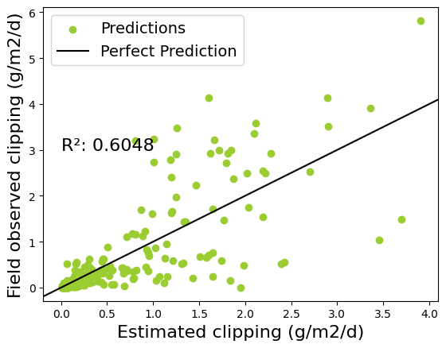

```python
#performance evaluation using scatter plot
plt.scatter(y_pred_rf, y_test, color='yellowgreen', label='Predictions')
plt.axline([0, 0], [1, 1], color='black', label="Perfect Prediction")
plt.annotate(f'R²: {r2_score(y_test, y_pred_rf):.4f}', (0, 3), fontsize=16)
plt.xlabel('Estimated clipping (g/m2/d)', fontsize=16)
plt.ylabel('Field observed clipping (g/m2/d)', fontsize=16)
plt.legend(fontsize=14)
plt.savefig('Model_test_scatterplot.png', dpi=1200)
plt.show()
```

6. XGBoost Regression Description:

Type: Non-parametric model (ensemble learning method, boosting technique).

Tuning Parameters: Several, including n_estimators, learning_rate, max_depth, subsample, etc.

Inference: Yes, you can perform inference and interpret the model.

Variable Selection: XGBoost can perform implicit variable selection through feature importance.

Standardization: XGBoost generally does not require feature scaling (standardization is not necessary), as it is a tree-based algorithm.

```python
#6. XGBoost
# 1. Define parameter grid
xgb_param_grid = {
    'n_estimators': [100, 200],
    'max_depth': [3, 5, 7],
    'learning_rate': [0.01, 0.1]
}
# 2. Set up custom KFold and GridSearchCV
kf = KFold(n_splits=4, shuffle=True, random_state=42)  # Custom CV with 4 folds
xgb = GridSearchCV(XGBRegressor(random_state=42), xgb_param_grid, cv=kf, scoring='neg_mean_squared_error')

# 3. Fit model
xgb.fit(X_train, y_train)

# 4. Store best model
models = {}
models['XGBoost'] = xgb.best_estimator_
```

```python
# 5. Predict on test set
y_pred_xgb = models['XGBoost'].predict(X_test)

# 6. Evaluate model
mae_xgb = mean_absolute_error(y_test, y_pred_xgb)
mse_xgb = mean_squared_error(y_test, y_pred_xgb)
rmse_xgb = np.sqrt(mse_xgb)
r2_xgb = r2_score(y_test, y_pred_xgb)

# 7. Compute CV RMSE
cv_mse_xgb = -xgb.cv_results_['mean_test_score'][xgb.best_index_]
cv_rmse_xgb = np.sqrt(cv_mse_xgb)

# 8. Print results
print("XGBoost Results:")
print(f"Best params: {xgb.best_params_}")
print(f"CV RMSE: {cv_rmse_xgb:.2f}")
print(f"Test MAE: {mae_xgb:.2f}, RMSE: {rmse_xgb:.2f}, R²: {r2_xgb:.2f}")
```

```
XGBoost Results:
Best params: {'learning_rate': 0.1, 'max_depth': 3, 'n_estimators': 100}
CV RMSE: 0.61
Test MAE: 0.30, RMSE: 0.60, R²: 0.60
```

4.7 Support Vector Machines (SVM) Description:

Type: Non-parametric model.

Tuning Parameters: C (regularization), kernel type (eg RBF), epsilon (margin).

Inference: No

Variable Selection: No

Standardization: Yes, required for SVM.

```python
#7. Support vector regression

# 1. Define parameter grid
svr_param_grid = {'C': [0.1, 1, 10], 'epsilon': [0.01, 0.1, 0.5]}

# 2. Set up custom KFold and GridSearchCV
kf = KFold(n_splits=4, shuffle=True, random_state=42)  # Custom CV with 4 folds
svr = GridSearchCV(SVR(kernel='rbf'), svr_param_grid, cv=kf, scoring='neg_mean_squared_error')

# 3. Fit model
svr.fit(X_train, y_train)

# 4. Store best model
models = {}
models['SVR'] = svr.best_estimator_
```

```python
# 5. Predict on test set
y_pred_svr = models['SVR'].predict(X_test)

# 6. Evaluate model
mae_svr = mean_absolute_error(y_test, y_pred_svr)
mse_svr = mean_squared_error(y_test, y_pred_svr)
rmse_svr = np.sqrt(mse_svr)
r2_svr = r2_score(y_test, y_pred_svr)

# 7. Compute CV RMSE
cv_mse_svr = -svr.cv_results_['mean_test_score'][svr.best_index_]
cv_rmse_svr = np.sqrt(cv_mse_svr)

# 8. Print results
print("SVR Results:")
print(f"Best params: {svr.best_params_}")
print(f"CV RMSE: {cv_rmse_svr:.2f}")
print(f"Test MAE: {mae_svr:.2f}, RMSE: {rmse_svr:.2f}, R²: {r2_svr:.2f}")
```

```
SVR Results:
Best params: {'C': 10, 'epsilon': 0.1}
CV RMSE: 0.62
Test MAE: 0.30, RMSE: 0.63, R²: 0.55
```

Step 5

Final model fiting and interpretation

## Model Metrics

| Model | MAE | RMSE | R² |
| --- | --- | --- | --- |
| kNN | 0.29 | 0.58 | 0.62 |
| Linear Regression | 0.40 | 0.67 | 0.50 |
| Lasso | 0.40 | 0.67 | 0.50 |
| GAM | 0.37 | 0.69 | 0.46 |
| Decision Tree | 0.41 | 0.73 | 0.41 |
| Random Forest | 0.30 | 0.59 | 0.60 |
| XGBoost | 0.30 | 0.60 | 0.60 |
| SVR | 0.30 | 0.63 | 0.55 |

Preferred Model: Random Forest.

Reason: Random forest have one of the best predictive performance (0.59 RMSE), handles non-linear relationships well, and is robust to overfitting with many predictors. Simplicity is traded for accuracy here. While kNN performs slightly better (RMSE = 0.58, R² = 0.62), Random Forest offers feature importance, enhancing interpretability. With so many predictors (99) and noisy data typical in agriculture, RF is also robust to overfitting and generalization than simple base models like decision tree. Thus, we choose RF to balance predictive ability and interpretability.

```python
# Fit the best model on the entire dataset
best_model = RandomForestRegressor(n_estimators=100, max_depth=None, random_state=42)
best_model.fit(X_normalized, y_imputed)
```

```
RandomForestRegressor(random_state=42)
```

```python
# Predict on the entire dataset (for evaluation)
y_pred = best_model.predict(X_normalized)

# Evaluate the model
mae = mean_absolute_error(y_imputed, y_pred)
mse = mean_squared_error(y_imputed, y_pred)
rmse = np.sqrt(mse)
r2 = r2_score(y_imputed, y_pred)

# Print results
print("Best Model (Random Forest) Results on Full Dataset:")
print(f"Parameters: {{'n_estimators': 100, 'max_depth': None}}")
print(f"MAE: {mae:.2f}, RMSE: {rmse:.2f}, R²: {r2:.2f}")
```

```
Best Model (Random Forest) Results on Full Dataset:
Parameters: {'n_estimators': 100, 'max_depth': None}
MAE: 0.11, RMSE: 0.22, R²: 0.94
```

Feature Importance

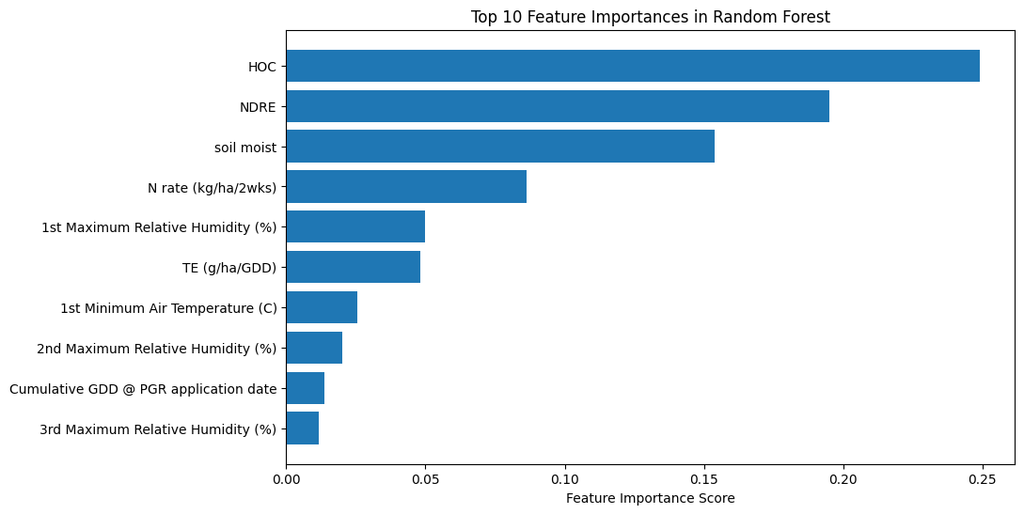

```
Top 10 Features and Importances:
HOC: 0.2492
NDRE: 0.1951
soil moist: 0.1539
N rate (kg/ha/2wks): 0.0864
1st Maximum Relative Humidity (%): 0.0499
TE (g/ha/GDD): 0.0483
1st Minimum Air Temperature (C): 0.0256
2nd Maximum Relative Humidity (%): 0.0201
Cumulative GDD @ PGR application date: 0.0138
3rd Maximum Relative Humidity (%): 0.0118
```

```
['Model 2023.joblib']
```

```python
# Fit final model (already done)
best_model = RandomForestRegressor(n_estimators=100, max_depth=None, random_state=42)
best_model.fit(X_normalized, y_imputed)

# Feature importance
importances = best_model.feature_importances_
indices = np.argsort(importances)[::-1]
top_features = X.columns[indices][:10]  # Top 10 features
top_importances = importances[indices][:10]

# Plot
plt.figure(figsize=(10, 6))
plt.barh(top_features, top_importances)
plt.xlabel('Feature Importance Score')
plt.title('Top 10 Feature Importances in Random Forest')
plt.gca().invert_yaxis()
plt.show()

# Print
print("Top 10 Features and Importances:")
for f, imp in zip(top_features, top_importances):
    print(f"{f}: {imp:.4f}")

# Save the model
dump(best_model, 'Model 2023.joblib')
```

```python
# Create the feature importance plot
feature_imp = pd.Series(best_model.feature_importances_, index=feature_names_model).sort_values(ascending=False)

top_features = feature_imp.index[:10].tolist()
top_features_indices = [X.columns.get_loc(feat) for feat in top_features]
fig, ax = plt.subplots(figsize=(25, 15), dpi=300)
display = PartialDependenceDisplay.from_estimator(
    best_model,
    X_normalized,
    features=top_features_indices,
    feature_names=X.columns.tolist(),
    target='clipping (g/m2/day)',
    ax=ax,
    grid_resolution=50
)
plt.suptitle("Partial Dependence Plots for Top 10 Features", fontsize=14)
plt.tight_layout()
plt.savefig('Partial_Dependence_Plots.png')
plt.show()
```

[figure not shown]

The partial dependence plots show that Height of cut (HOC) and nitrogen rate drives clipping yield and environmental factors such as humidity and temperature also affects clipping yield prediction. As expected, the PDP plots shows that higher values of HOC and PGR reduces predicted clipping yield, while higher N rate and NDRE increases prediction. Drops in predictions at specific levels of maximum relative humidity (1st, 2nd, and 3rd) suggests some threshold effect. A sharp rise in predictions was seen at higher values of air temperature. TE (PGR) showed slight negative impact on clipping yield predictions. Cumulative GDD @PGR application date remains mostly flat at lower values, decreases slightly and then remains flat at higher values, while NDRE remains mostly flat but increases after 0.5.